# Title of Blog Post Deliverable

### 2.1.3 Cdf vs Ecdf

#### 2.1.3.1 Glycohemoglobin

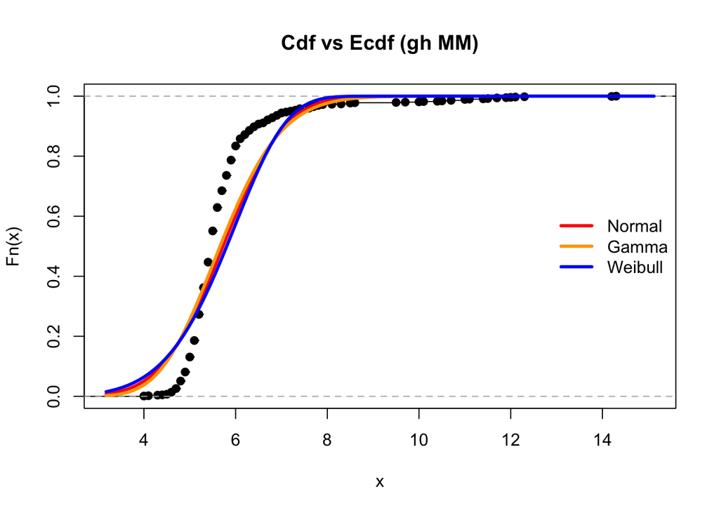

```r
plot(ecdf(gh),main="Cdf vs Ecdf (gh MM)")
curve(pnorm(x, mean = nor_mean_hat_gh, sd = nor_sd_hat_gh), add=TRUE, lwd = 3, col="red")
curve(pgamma(x, scale = gamma_scale_hat_gh, shape = gamma_shape_hat_gh), add=TRUE, lwd = 3, col="orange")
curve(pweibull(x, scale = wb_scale_hat_gh,shape = wb_shape_hat_gh ), add=TRUE, lwd = 3, col="blue")
legend(
    "right"
    ,c('Normal','Gamma','Weibull')
    ,col = c('red','orange','blue')
    ,lwd =3
    ,bty = "n"
)
```

From the above graphic, for the Glycohemoglobin, these three distributions are not perfect to model it because their cdf distributions are not very close to the ecdf distribution.

#### 2.1.3.2 Height

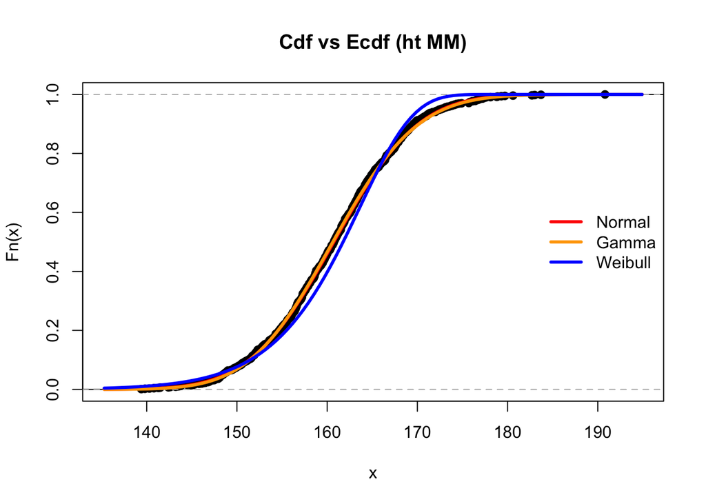

```r
plot(ecdf(ht),main="Cdf vs Ecdf (ht MM)")
curve(pnorm(x, mean = nor_mean_hat_ht, sd = nor_sd_hat_ht), add=TRUE, lwd = 3, col="red")
curve(pgamma(x, scale = gamma_scale_hat_ht, shape = gamma_shape_hat_ht), add=TRUE, lwd = 3, col="orange")
curve(pweibull(x, scale = wb_scale_hat_ht,shape = wb_shape_hat_ht), add=TRUE, lwd = 3, col="blue")
legend(
    "right"
    ,c('Normal','Gamma','Weibull')
    ,col = c('red','orange','blue')
    ,lwd =3
    ,bty = "n"
)
```

From the above graphic, for the height, normal and gamma distributions are good at modeling it but the weibull distribution has a little deviation from the ecdf distribution.

### 2.1.4 Quantile vs QQ plot

#### 2.1.4.1 Glycohemoglobin

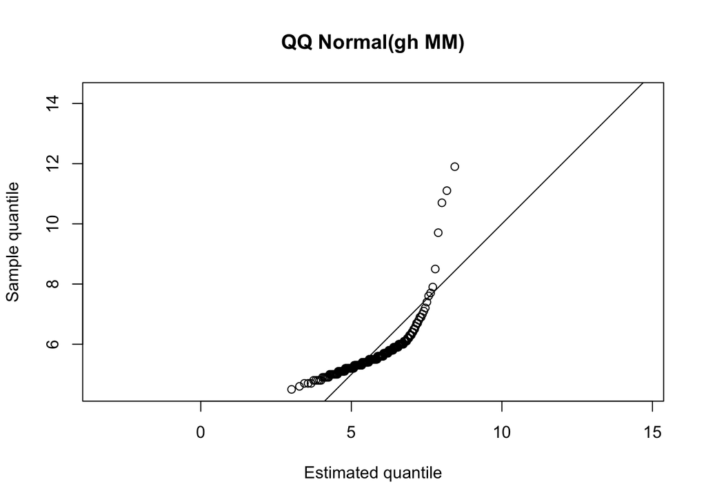

```r
x_normal_gh <- qnorm((1:200)/200,mean = nor_mean_hat_gh, sd = nor_sd_hat_gh)
x_gamma_gh <- qgamma((1:200)/200,scale = gamma_scale_hat_gh, shape = gamma_shape_hat_gh)
x_wb_gh <- qweibull((1:200)/200,scale = wb_scale_hat_gh,shape = wb_shape_hat_gh)
y_gh <- quantile(gh,probs = (1:200)/200)
plot(x_normal_gh,y_gh,asp=1,xlab = "Estimated quantile",ylab ="Sample quantile",main = "QQ Normal(gh MM)")
abline(0,1)
```

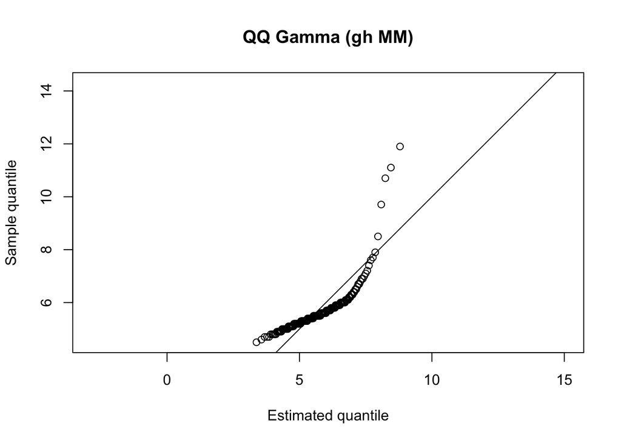

```r
plot(x_gamma_gh,y_gh,asp=1,xlab = "Estimated quantile",ylab ="Sample quantile",main = "QQ Gamma (gh MM)")
abline(0,1)
```

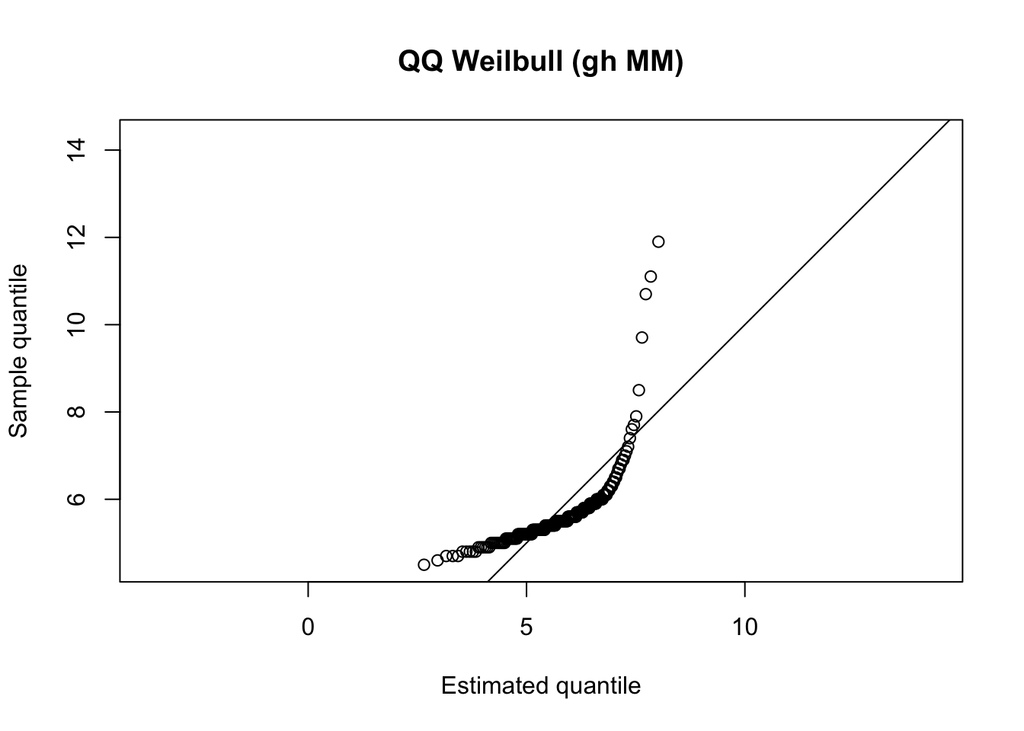

```r
plot(x_wb_gh,y_gh,asp=1,xlab = "Estimated quantile",ylab ="Sample quantile", main = "QQ Weilbull (gh MM)")
abline(0,1)
```

From the above graphic, for the Glycohemoglobin, these three distributions are not perfect to model it because most of their points are not on the line y=x.

#### 2.1.4.2 Height

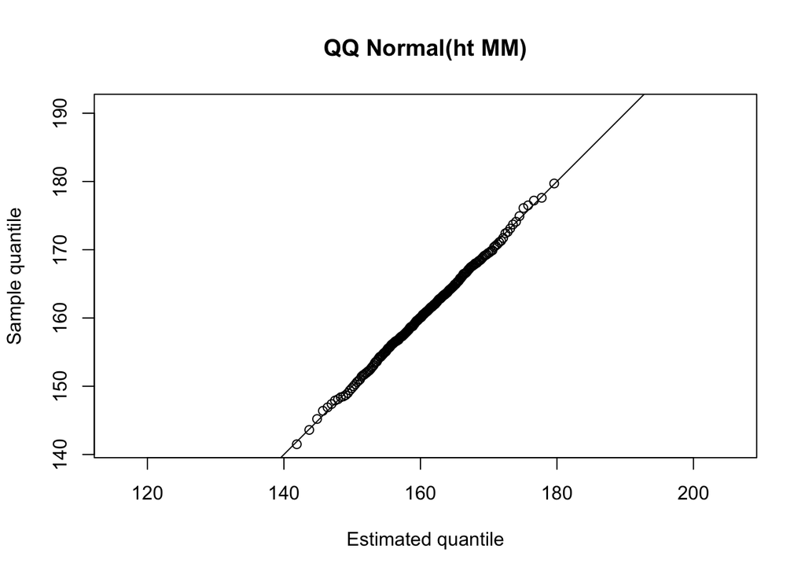

```r
x_normal_ht <- qnorm((1:200)/200,mean = nor_mean_hat_ht, sd = nor_sd_hat_ht)
x_gamma_ht <- qgamma((1:200)/200,scale = gamma_scale_hat_ht, shape = gamma_shape_hat_ht)
x_wb_ht <- qweibull((1:200)/200,scale = wb_scale_hat_ht,shape = wb_shape_hat_ht)
y_ht <- quantile(ht,probs = (1:200)/200)
plot(x_normal_ht,y_ht,asp=1,xlab = "Estimated quantile",ylab ="Sample quantile",main = "QQ Normal(ht MM)" )
abline(0,1)
```

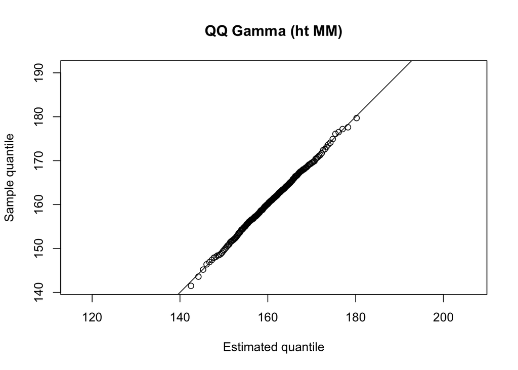

```r
plot(x_gamma_ht,y_ht,asp=1,xlab = "Estimated quantile",ylab ="Sample quantile",main = "QQ Gamma (ht MM)")
abline(0,1)
```

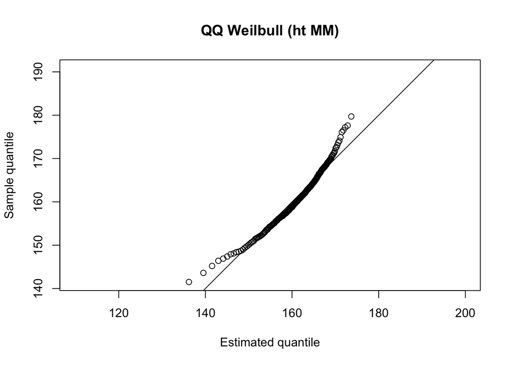

```r
plot(x_wb_ht,y_ht,asp=1,xlab = "Estimated quantile",ylab ="Sample quantile", main = "QQ Weilbull (ht MM)")
abline(0,1)
```

From the above graphic, for the height, normal and gamma distributions are good at modeling it but some points in the Weibull distribution deviate from the y=x line

### 2.1.5 Median

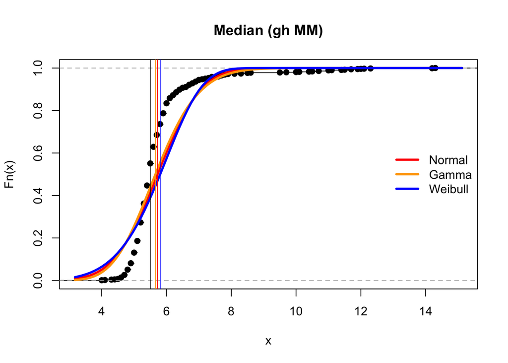

```r
# calulate median for different distributions
median_norm_gh <- qnorm(0.5,mean = nor_mean_hat_gh, sd = nor_sd_hat_gh)
median_gamma_gh <- qgamma(0.5,scale = gamma_scale_hat_gh, shape = gamma_shape_hat_gh)
median_wb_gh <- qweibull(0.5,scale = wb_scale_hat_gh,shape = wb_shape_hat_gh)

plot(ecdf(gh),main="Median (gh MM)")
curve(pnorm(x, mean = nor_mean_hat_gh, sd = nor_sd_hat_gh), add=TRUE, lwd = 3, col="red")
curve(pgamma(x, scale = gamma_scale_hat_gh, shape = gamma_shape_hat_gh), add=TRUE, lwd = 3, col="orange")
curve(pweibull(x, scale = wb_scale_hat_gh,shape = wb_shape_hat_gh ), add=TRUE, lwd = 3, col="blue")
legend(
    "right"
    ,c('Normal','Gamma','Weibull')
    ,col = c('red','orange','blue')
    ,lwd =3
    ,bty = "n"
)
# add vertical lines to indicate distributions' median and sample median
abline(v =median_norm_gh, col = "red")
abline(v =median_gamma_gh, col = "orange")
abline(v =median_wb_gh, col = "blue")
abline(v = quantile(gh,0.5),col="black")
```

From the above graphic, for the Glycohemoglobin, these three distributions are not perfect to model it because their medians have obvious deviations from the sample median.

#### 2.1.5.1 Height

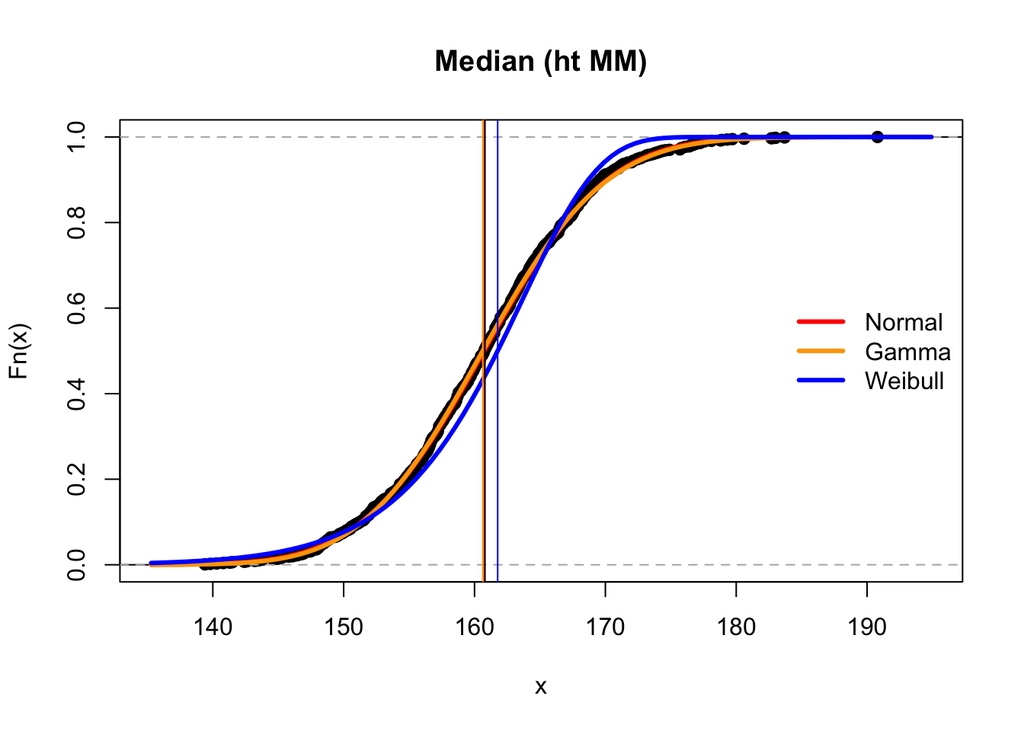

```r
# ht
median_norm_ht <- qnorm(0.5,mean = nor_mean_hat_ht, sd = nor_sd_hat_ht)
median_gamma_ht <- qgamma(0.5,scale = gamma_scale_hat_ht, shape = gamma_shape_hat_ht)
median_wb_ht <- qweibull(0.5,scale = wb_scale_hat_ht,shape = wb_shape_hat_ht)

plot(ecdf(ht),main="Median (ht MM)")
curve(pnorm(x, mean = nor_mean_hat_ht, sd = nor_sd_hat_ht), add=TRUE, lwd = 3, col="red")
curve(pgamma(x, scale = gamma_scale_hat_ht, shape = gamma_shape_hat_ht), add=TRUE, lwd = 3, col="orange")
curve(pweibull(x, scale = wb_scale_hat_ht,shape = wb_shape_hat_ht), add=TRUE, lwd = 3, col="blue")
legend(
    "right"
    ,c('Normal','Gamma','Weibull')
    ,col = c('red','orange','blue')
    ,lwd =3
    ,bty = "n"
)
abline(v =median_norm_ht, col = "red")
abline(v =median_gamma_ht, col = "orange")
abline(v =median_wb_ht, col = "blue")
abline(v = quantile(ht,0.5),col="black")
```

From the above graphic, for the height, normal and gamma distributions are good at modeling it but the weibull distribution’s median has an obvious deviation from the sample median.

## 2.2 MLE

The first step to use MLE is to find which type of distribution can be used to describe the data. In this case, we have three choices normal, gamma and, weibull distribution. Then, we need to decide parameters of these distributions. MLE is a method that tries a lot of possible parameters and find the parameters that can maximum the probability of obtaining the sample data. In other word, we need to find parameters that can maximum the following formula
$$f(x_1,x_2,...,x_n|parameters)$$
In R, we need to use mle to achieve this task. mle needs two primary parameters:1. negative likelihood function which needs to be minimized 2. starting point for the coefficient vector.

### 2.2.1 Calculate parameters

```r
# norm and gh
# add "-" to be compatible with mle's requirement
ll_norm_gh  <- function(mean,sd){
  -sum(dnorm(gh,mean = mean,sd = sd,log=T))
}
z_norm_gh <- mle(minuslogl=ll_norm_gh, start=list(mean=1,sd=1),
                 method = "L-BFGS-B",
                 lower = c(0,0.01))

print(paste("Mean of normal distribution of Glycohemoglobin:",coef(z_norm_gh)[1]))
```

```
## [1] "Mean of normal distribution of Glycohemoglobin: 5.72459989153527"
```

```r
print(paste("Standard deviation of normal distribution of Glycohemoglobin:",coef(z_norm_gh)[2]))
```

```
## [1] "Standard deviation of normal distribution of Glycohemoglobin: 1.05172048445"
```

```r
# norm and ht
ll_norm_ht  <- function(mean,sd){
  -sum(dnorm(ht,mean = mean,sd = sd,log=T))
}
z_norm_ht <- mle(minuslogl=ll_norm_ht, start=list(mean=1,sd=1),
                 method = "L-BFGS-B",
                 lower = c(0,0.01))

print(paste("Mean of normal distribution of Height:",coef(z_norm_ht)[1]))
```

```
## [1] "Mean of normal distribution of Height: 160.74190054476"
```

```r
print(paste("Standard deviation of normal distribution of Height:",coef(z_norm_ht)[2]))
```

```
## [1] "Standard deviation of normal distribution of Height: 7.31650217722"
```

```r
# gamma and gh
ll_gamma_gh  <- function(shape,scale){
  -sum(dgamma(gh, shape = shape ,scale = scale,log=T))
}
z_gamma_gh <- mle(minuslogl=ll_gamma_gh, start=list(shape=1,scale=1),lower = c(0,0.01))

print(paste("Shape of gamma distribution of Glycohemoglobin:",coef(z_gamma_gh)[1]))
```

```
## [1] "Shape of gamma distribution of Glycohemoglobin: 40.7065048382251"
```

```r
print(paste("Scale of gamma distribution of Glycohemoglobin:",coef(z_gamma_gh)[2]))
```

```
## [1] "Scale of gamma distribution of Glycohemoglobin: 0.140635826831459"
```

```r
# gamma and ht
ll_gamma_ht <- function(shape,scale){
  -sum(dgamma(ht, shape = shape ,scale = scale,log=T))
}
z_gamma_ht <- mle(minuslogl=ll_gamma_ht, start=list(shape=1,scale=1),lower = c(0,0.01))

print(paste("Shape of gamma distribution of Height:",coef(z_gamma_ht)[1]))
```

```
## [1] "Shape of gamma distribution of Height: 479.61269588424"
```

```r
print(paste("Scale of gamma distribution of Height:",coef(z_gamma_ht)[2]))
```

```
## [1] "Scale of gamma distribution of Height: 0.335151374021394"
```

```r
# wb and gh
ll_wb_gh  <- function(shape,scale){
  -sum(dweibull(gh, shape = shape ,scale = scale,log=T))
}
z_wb_gh <- mle(minuslogl=ll_wb_gh, start=list(shape=1,scale=1),lower = c(0,0.01))

print(paste("Shape of Weibull distribution of Glycohemoglobin:",coef(z_wb_gh)[1]))
```

```
## [1] "Shape of Weibull distribution of Glycohemoglobin: 4.12525369423587"
```

```r
print(paste("Scale of Weibull distribution of Glycohemoglobin:",coef(z_wb_gh)[2]))
```

```
## [1] "Scale of Weibull distribution of Glycohemoglobin: 6.17388481107831"
```

```r
# wb and ht
ll_wb_ht  <- function(shape,scale){
  -sum(dweibull(ht, shape = shape ,scale = scale,log=T))
}
z_wb_ht <- mle(minuslogl=ll_wb_ht, start=list(shape=1,scale=1),lower = c(0,0.01))

print(paste("Shape of Weibull distribution of Height:",coef(z_wb_ht)[1]))
```

```
## [1] "Shape of Weibull distribution of Height: 21.8539787569256"
```

```r
print(paste("Scale of Weibull distribution of height:",coef(z_wb_ht)[2]))
```

```
## [1] "Scale of Weibull distribution of height: 164.247191593493"
```

### 2.2.2 Pdf vs Histogram

#### 2.2.2.1 Glycohemoglobin

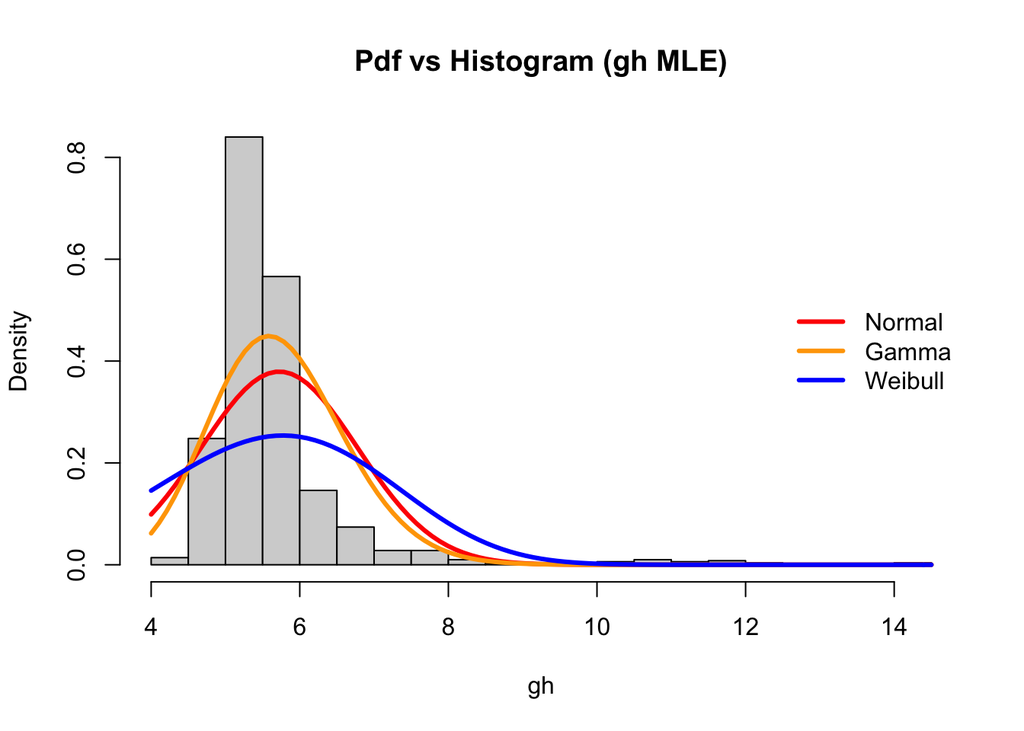

```r
hist(gh,breaks=20,freq=FALSE,main = "Pdf vs Histogram (gh MLE)")
curve(dnorm(x,mean = coef(z_norm_gh)[1],sd = coef(z_norm_gh)[2]),lwd=3,add=TRUE,col="red")
curve(dgamma(x,shape = coef(z_gamma_gh)[1],scale = coef(z_gamma_gh)[2]),lwd=3,add=TRUE,col="orange")
curve(dweibull(x,shape = coef(z_wb_gh)[1],scale = coef(z_wb_gh)[2]),lwd=3,add=TRUE,col="blue")
legend(
    "right"
    ,c('Normal','Gamma','Weibull')
    ,col = c('red','orange','blue')
    ,lwd =3
    ,bty = "n"
)
```

From the above graphic, for the Glycohemoglobin, these three distributions are not perfect to model it because their pdf distributions are not very close to the histogram.

#### 2.2.2.2 Height

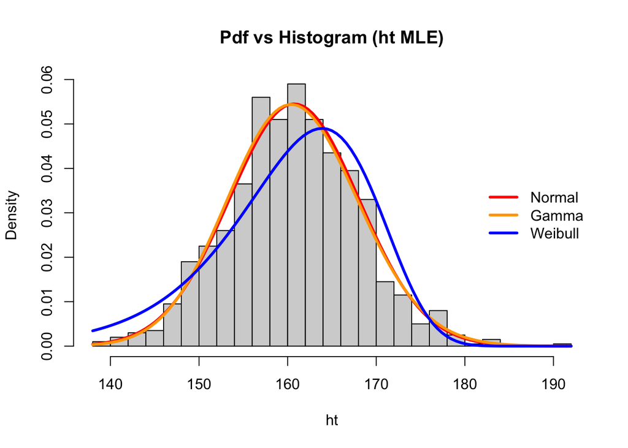

```r
hist(ht,breaks=20,freq=FALSE,,main = "Pdf vs Histogram (ht MLE)")
curve(dnorm(x,mean = coef(z_norm_ht)[1],sd = coef(z_norm_ht)[2]),lwd=3,add=TRUE,col="red")
curve(dgamma(x,shape = coef(z_gamma_ht)[1],scale = coef(z_gamma_ht)[2]),lwd=3,add=TRUE,col="orange")
curve(dweibull(x,shape = coef(z_wb_ht)[1],scale = coef(z_wb_ht)[2]),lwd=3,add=TRUE,col="blue")
legend(
    "right"
    ,c('Normal','Gamma','Weibull')
    ,col = c('red','orange','blue')
    ,lwd =3
    ,bty = "n"
)
```

From the above graphic, for the height, normal and gamma distributions are good at modeling it but the weibull distribution is not a very good choice to model it.

### 2.2.3 Cdf vs Ecdf

#### 2.2.3.1 Glycohemoglobin

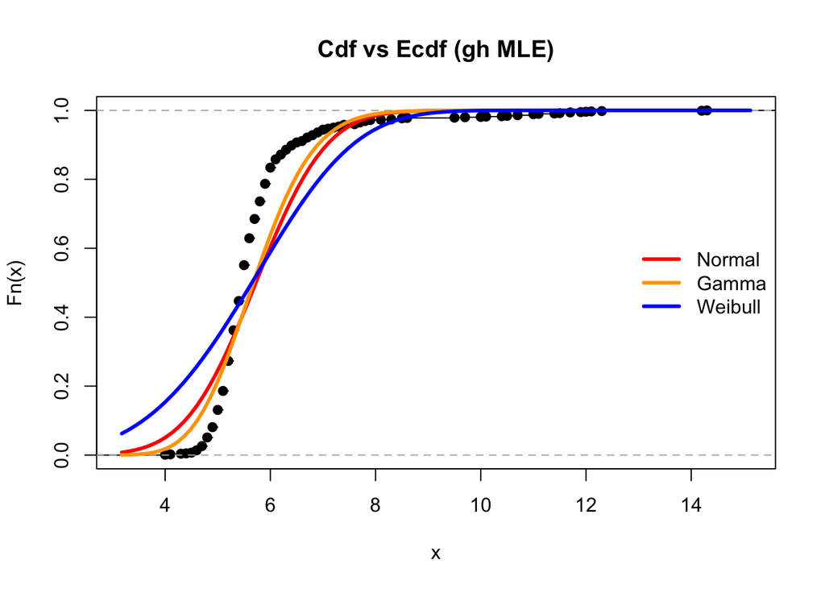

```r
plot(ecdf(gh), main ="Cdf vs Ecdf (gh MLE)")
curve(pnorm(x, mean = coef(z_norm_gh)[1],sd = coef(z_norm_gh)[2]), add=TRUE, lwd = 3, col="red")
curve(pgamma(x, shape = coef(z_gamma_gh)[1],scale = coef(z_gamma_gh)[2]), add=TRUE, lwd = 3, col="orange")
curve(pweibull(x, shape = coef(z_wb_gh)[1],scale = coef(z_wb_gh)[2]), add=TRUE, lwd = 3, col="blue")
legend(
    "right"
    ,c('Normal','Gamma','Weibull')
    ,col = c('red','orange','blue')
    ,lwd =3
    ,bty = "n"
)
```

From the above graphic, for the Glycohemoglobin, these three distributions are not perfect to model it because their cdf distributions are not very close to the ecdf distribution.

#### 2.2.3.2 Height

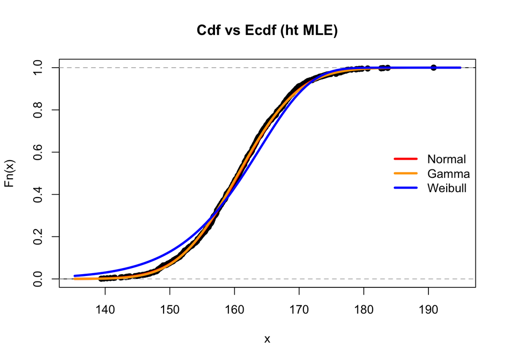

```r
plot(ecdf(ht),main ="Cdf vs Ecdf (ht MLE)")
curve(pnorm(x, mean = coef(z_norm_ht)[1],sd = coef(z_norm_ht)[2]), add=TRUE, lwd = 3, col="red")
curve(pgamma(x, shape = coef(z_gamma_ht)[1],scale = coef(z_gamma_ht)[2]), add=TRUE, lwd = 3, col="orange")
curve(pweibull(x, shape = coef(z_wb_ht)[1],scale = coef(z_wb_ht)[2]), add=TRUE, lwd = 3, col="blue")
legend(
    "right"
    ,c('Normal','Gamma','Weibull')
    ,col = c('red','orange','blue')
    ,lwd =3
    ,bty = "n"
)
```

From the above graphic, for the height, normal and gamma distributions are good at modeling it but the weibull distribution has a little deviation from the ecdf distribution.

### 2.2.4 Quantile vs QQ plot

#### 2.2.4.1 Glycohemoglobin

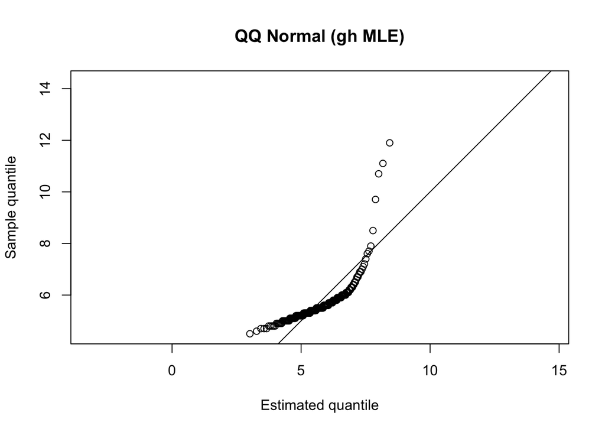

```r
x_normal_gh <- qnorm((1:200)/200,mean = coef(z_norm_gh)[1],sd = coef(z_norm_gh)[2])
x_gamma_gh <- qgamma((1:200)/200,shape = coef(z_gamma_gh)[1],scale = coef(z_gamma_gh)[2])
x_wb_gh <- qweibull((1:200)/200, shape = coef(z_wb_gh)[1],scale = coef(z_wb_gh)[2])
y_gh <- quantile(gh,probs = (1:200)/200)

plot(x_normal_gh,y_gh,asp=1,xlab = "Estimated quantile",ylab ="Sample quantile",main = "QQ Normal (gh MLE)")
abline(0,1)
```

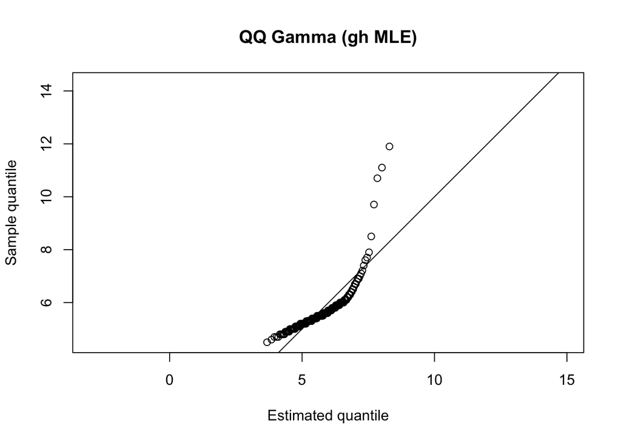

```r
plot(x_gamma_gh,y_gh,asp=1,xlab = "Estimated quantile",ylab ="Sample quantile",main = "QQ Gamma (gh MLE)")
abline(0,1)
```

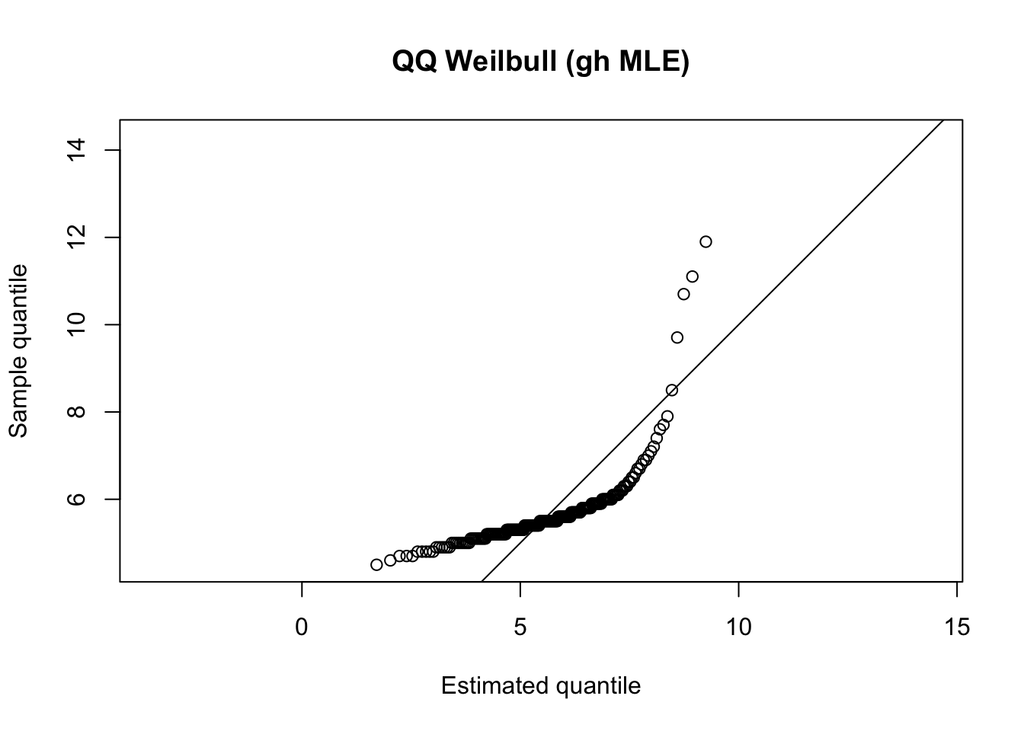

```r
plot(x_wb_gh,y_gh,asp=1,xlab = "Estimated quantile",ylab ="Sample quantile", main = "QQ Weilbull (gh MLE)")
abline(0,1)
```

From the above graphics, for the Glycohemoglobin, these three distributions are not perfect to model it because most of their points are not on the line y=x.

#### 2.2.4.2 Height

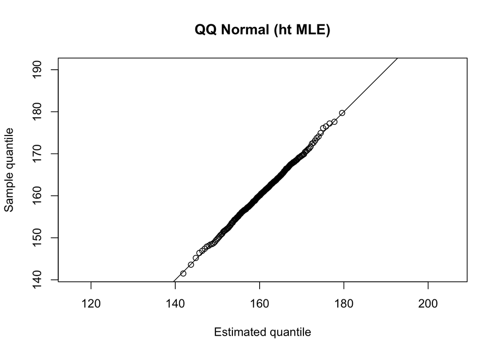

```r
x_normal_ht <- qnorm((1:200)/200, mean = coef(z_norm_ht)[1],sd = coef(z_norm_ht)[2])
x_gamma_ht <- qgamma((1:200)/200,shape = coef(z_gamma_ht)[1],scale = coef(z_gamma_ht)[2])
x_wb_ht <- qweibull((1:200)/200,shape = coef(z_wb_ht)[1],scale = coef(z_wb_ht)[2])
y_ht <- quantile(ht,probs = (1:200)/200)

plot(x_normal_ht,y_ht,asp=1,xlab = "Estimated quantile",ylab ="Sample quantile",main = "QQ Normal (ht MLE)" )
abline(0,1)
```

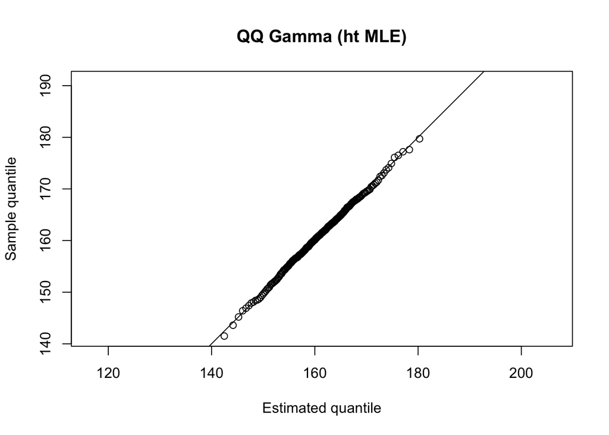

```r
plot(x_gamma_ht,y_ht,asp=1,xlab = "Estimated quantile",ylab ="Sample quantile",main = "QQ Gamma (ht MLE)")
abline(0,1)
```

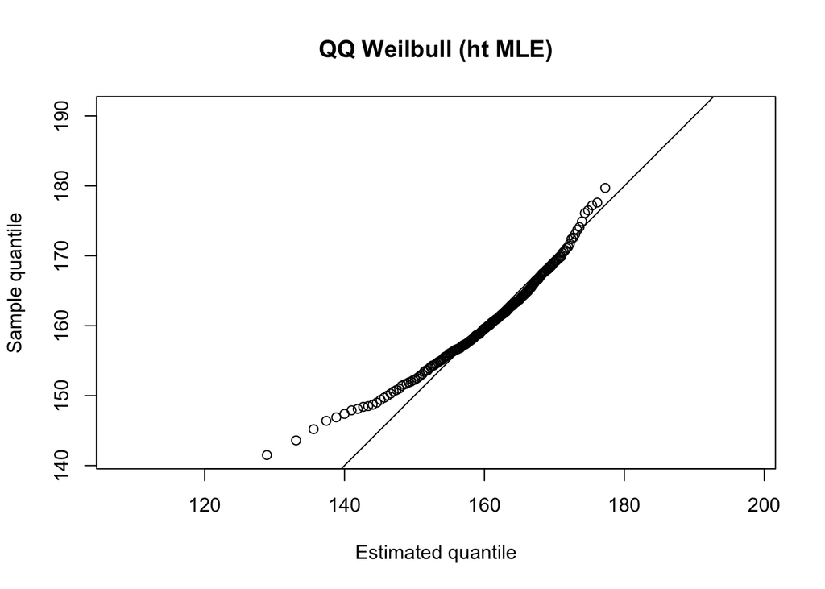

```r
plot(x_wb_ht,y_ht,asp=1,xlab = "Estimated quantile",ylab ="Sample quantile", main = "QQ Weilbull (ht MLE)")
abline(0,1)
```

From the above graphic, for the height, normal and gamma distributions are good at modeling it but some points in the Weibull distribution deviate from the y=x line

### 2.2.5 Median

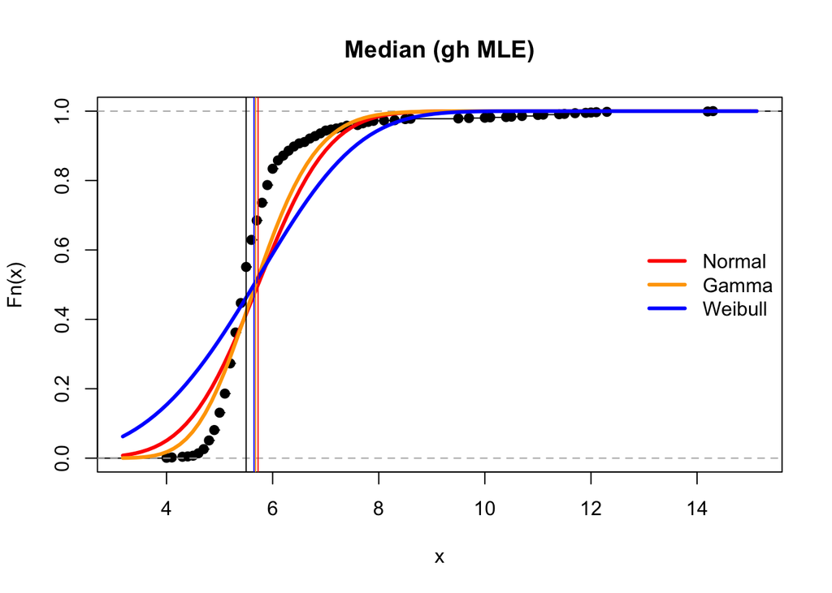

```r
# gh
median_norm_gh <- qnorm(0.5,mean = coef(z_norm_gh)[1],sd = coef(z_norm_gh)[2])
median_gamma_gh <- qgamma(0.5,shape = coef(z_gamma_gh)[1],scale = coef(z_gamma_gh)[2])
median_wb_gh <- qweibull(0.5,shape = coef(z_wb_gh)[1],scale = coef(z_wb_gh)[2])

plot(ecdf(gh),main="Median (gh MLE)")
curve(pnorm(x, mean = coef(z_norm_gh)[1],sd = coef(z_norm_gh)[2]), add=TRUE, lwd = 3, col="red")
curve(pgamma(x, shape = coef(z_gamma_gh)[1],scale = coef(z_gamma_gh)[2]), add=TRUE, lwd = 3, col="orange")
curve(pweibull(x, shape = coef(z_wb_gh)[1],scale = coef(z_wb_gh)[2]), add=TRUE, lwd = 3, col="blue")
legend(
    "right"
    ,c('Normal','Gamma','Weibull')
    ,col = c('red','orange','blue')
    ,lwd =3
    ,bty = "n"
)
abline(v =median_norm_gh, col = "red")
abline(v =median_gamma_gh, col = "orange")
abline(v =median_wb_gh, col = "blue")
abline(v = quantile(gh,0.5),col="black")
```

From the above graphic, for the Glycohemoglobin, these three distributions are not perfect to model it because their medians have obvious deviations from the sample median.

#### 2.2.5.1 Height

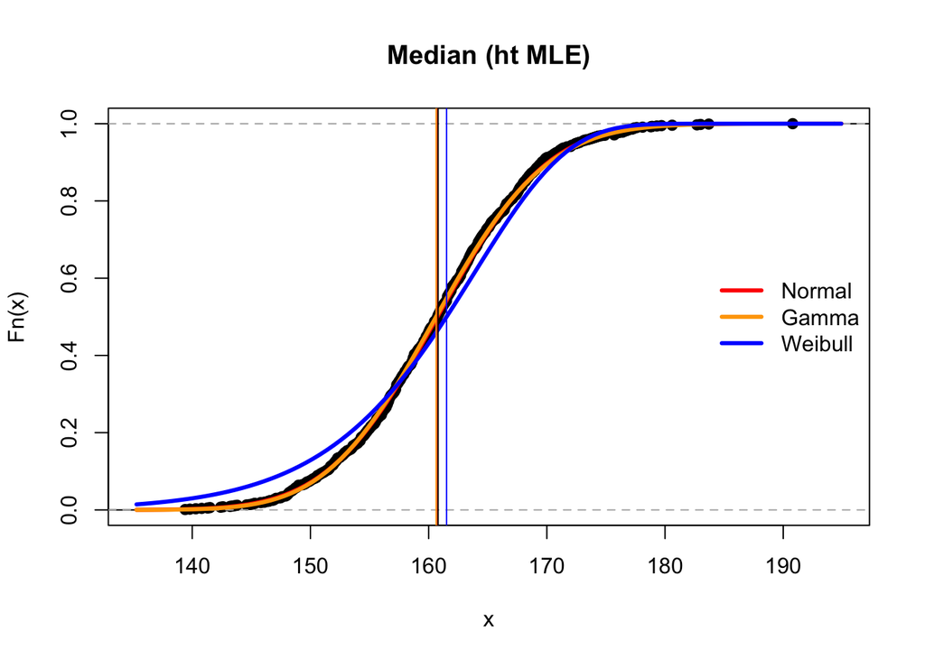

```r
# ht
median_norm_ht <- qnorm(0.5,mean = coef(z_norm_ht)[1],sd = coef(z_norm_ht)[2])
median_gamma_ht <- qgamma(0.5,shape = coef(z_gamma_ht)[1],scale = coef(z_gamma_ht)[2])
median_wb_ht <- qweibull(0.5,shape = coef(z_wb_ht)[1],scale = coef(z_wb_ht)[2])

plot(ecdf(ht),,main="Median (ht MLE)")
curve(pnorm(x, mean = coef(z_norm_ht)[1],sd = coef(z_norm_ht)[2]), add=TRUE, lwd = 3, col="red")
curve(pgamma(x, shape = coef(z_gamma_ht)[1],scale = coef(z_gamma_ht)[2]), add=TRUE, lwd = 3, col="orange")
curve(pweibull(x, shape = coef(z_wb_ht)[1],scale = coef(z_wb_ht)[2]), add=TRUE, lwd = 3, col="blue")
legend(
    "right"
    ,c('Normal','Gamma','Weibull')
    ,col = c('red','orange','blue')
    ,lwd =3
    ,bty = "n"
)
abline(v =median_norm_ht, col = "red")
abline(v =median_gamma_ht, col = "orange")
abline(v =median_wb_ht, col = "blue")
abline(v = quantile(ht,0.5),col="black")
```

# 3 Conclusion

In this case, MM and MLE give the same result that for modeling adult females’ glycohemoglobin, normal,gamma, and weibull distributions are not suitable; for modeling adult female’s height, normal and gamma distributions work well but weibull distribution is not very suitable.

# 4 Take-home messages

1. MM and MLE are parametric methods to make statistical estimation. In other word, they estimate distributions’ parameters
2. MM is more direct and easy.
3. MLE is more complicated but it’s less sensitive to outliers
4. The prerequisite of using MM and MLE is to select a suitable distribution model otherwise, like the glycohemoglobin example, the final result will not be good.